# Real HW2

JP Torres

November 13, 2018

## Overview

A company’s growth will always be driven by sales. Given the large market and limited bandwidth, it is important that the sales team focus on viable options. We will be looking at Nasdaq’s current IR Insight client base and some of our customer’s fundamentals to see if any can be used for better targeting.

## Definition of terms

Nasdaq IR Insight is a multiplatform Investor Relations program leveraging time saving tools to gain unique insights into all IR program decisions. Here we are showing subscription spend of clients. Broker Coverage is the number of brokers who cover the company’s listings and therefore provides research to include recommendation and estimates. Market Capitalization is the company’s US Dollar value of the company’s outstanding shares. This is used as a measure to determine a company’s size. Free Float are the shares available in the market. We will be looking at the correlation of these company specific fundamentals in relation to their IR Insight subscription spend.

```
##                 IRInsight Broker_Coverage
## IRInsight       1.0000000       0.3615505
## Broker_Coverage 0.3615505       1.0000000
```

```
##              IRInsight MarketCapUSD
## IRInsight    1.0000000    0.3561114
## MarketCapUSD 0.3561114    1.0000000
```

```
##           IRInsight FreeFloat
## IRInsight 1.0000000 0.1733357
## FreeFloat 0.1733357 1.0000000
```

## Initial Findings

Using Pearson’s correlation method, association of the fundmentals is weak especially free float.

## Charts

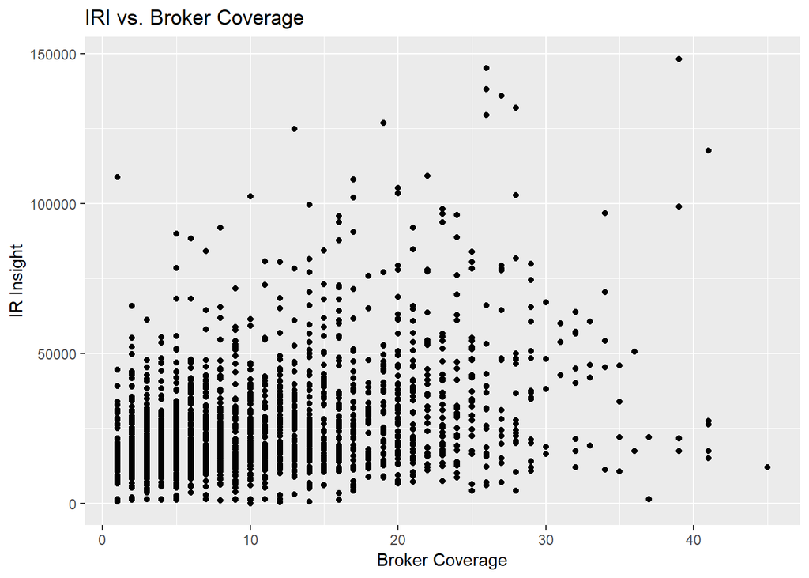

```r
library(dplyr)
library(ggplot2)
IR <- read.csv("IR Clients.csv")
iri_bc <-select(IR, IRInsight, Broker_Coverage)
iri_bc_na <- iri_bc[complete.cases(iri_bc),]
iri_mc <-select(IR, IRInsight, MarketCapUSD)
iri_mc_na <- iri_mc[complete.cases(iri_mc),]
iri_ff <-select(IR, IRInsight, FreeFloat)
iri_ff_na <- iri_ff[complete.cases(iri_ff),]
qplot(x =  iri_bc_na$Broker_Coverage, y =  iri_bc_na$IRInsight, main = "IRI vs. Broker Coverage") + labs(x = "Broker Coverage", y = "IR Insight")
```

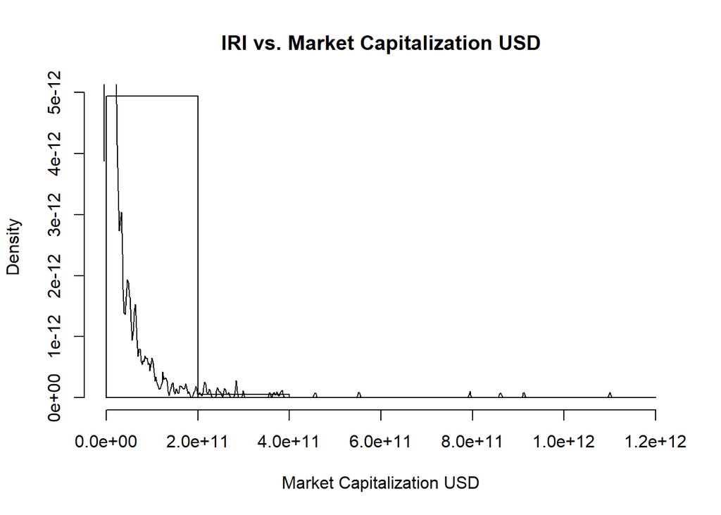

```r
hist(iri_mc_na$MarketCapUSD,breaks = 5, prob =TRUE, xlab = "Market Capitalization USD", main = "IRI vs. Market Capitalization USD")
lines(density(iri_mc_na$MarketCapUSD))
```

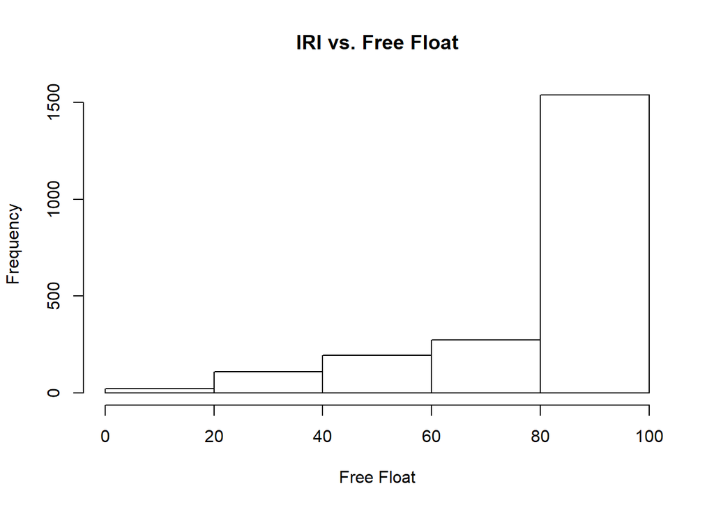

```r
hist(iri_ff_na$FreeFloat, breaks = 5, xlab = "Free Float", main = "IRI vs. Free Float")
```